# Gini_OECD

coop711

2015년 5월 4일

OECD 국가들의 Gini계수 읽어들이기. 세전과 세후로 구분. 자료구조로 인하여 `sep="\t"`을 사용한 것에 유의

```r
Gini.b.tax<-read.table(file="../data/Gini_before_tax.txt", header=F, sep="\t")
Gini.a.tax<-read.table(file="../data/Gini_after_tax.txt", header=F, sep="\t")
str(Gini.b.tax)
```

```
## 'data.frame':    34 obs. of  8 variables:
##  $ V1: chr  "Australia" "Austria" "Belgium" "Canada" ...
##  $ V2: num  NA NA NA 0.385 NA NA NA NA 0.343 NA ...
##  $ V3: num  NA NA 0.449 0.395 NA NA 0.373 NA 0.387 0.38 ...
##  $ V4: num  NA NA NA 0.403 NA NA 0.396 NA NA 0.37 ...
##  $ V5: num  0.467 NA 0.472 0.43 0.441 0.442 0.417 NA 0.479 0.473 ...
##  $ V6: num  0.476 NA 0.464 0.44 NA 0.472 0.415 NA 0.478 0.49 ...
##  $ V7: num  0.465 0.433 0.494 0.436 0.414 0.474 0.417 0.504 0.483 0.485 ...
##  $ V8: num  0.468 0.472 0.469 0.441 0.426 0.444 0.416 0.458 0.465 0.483 ...
```

2000년 후반 자료만 모아서 새로운 data frame 구성

```r
Gini.b.a<-data.frame(Country=Gini.b.tax$V1, Before=Gini.b.tax$V8, After=Gini.a.tax$V8)
Gini.b.a
```

```
##            Country Before After
## 1        Australia  0.468 0.336
## 2          Austria  0.472 0.261
## 3          Belgium  0.469 0.259
## 4           Canada  0.441 0.324
## 5            Chile  0.426 0.394
## 6   Czech_Republic  0.444 0.256
## 7          Denmark  0.416 0.248
## 8          Estonia  0.458 0.315
## 9          Finland  0.465 0.259
## 10          France  0.483 0.293
## 11         Germany  0.504 0.295
## 12          Greece  0.436 0.307
## 13         Hungary  0.466 0.272
## 14         Iceland  0.382 0.301
```

[output cut: 20 more lines]

세전과 세후의 Gini 계수 차이를 개선도(Improvement)라고 명명.

```r
Gini.b.a$Improvement<-Gini.b.a[,2]-Gini.b.a[,3]
Gini.b.a
```

```
##            Country Before After Improvement
## 1        Australia  0.468 0.336       0.132
## 2          Austria  0.472 0.261       0.211
## 3          Belgium  0.469 0.259       0.210
## 4           Canada  0.441 0.324       0.117
## 5            Chile  0.426 0.394       0.032
## 6   Czech_Republic  0.444 0.256       0.188
## 7          Denmark  0.416 0.248       0.168
## 8          Estonia  0.458 0.315       0.143
## 9          Finland  0.465 0.259       0.206
## 10          France  0.483 0.293       0.190
## 11         Germany  0.504 0.295       0.209
## 12          Greece  0.436 0.307       0.129
## 13         Hungary  0.466 0.272       0.194
## 14         Iceland  0.382 0.301       0.081
```

[output cut: 20 more lines]

개선도가 낮은 순서로 나열. 아일랜드는 세전 자료가 없기 때문에 맨 뒤로 위치.

```r
Gini.b.a[order(Gini.b.a$Improvement), ]
```

```
##            Country Before After Improvement
## 20          Mexico  0.494 0.476       0.018
## 28     South_Korea  0.344 0.315       0.029
## 5            Chile  0.426 0.394       0.032
## 32          Turkey  0.470 0.409       0.061
## 14         Iceland  0.382 0.301       0.081
## 31     Switzerland  0.409 0.303       0.106
## 34   United_States  0.486 0.378       0.108
## 33  United_Kingdom  0.456 0.345       0.111
## 4           Canada  0.441 0.324       0.117
## 22     New_Zealand  0.455 0.330       0.125
## 16          Israel  0.498 0.371       0.127
## 12          Greece  0.436 0.307       0.129
## 1        Australia  0.468 0.336       0.132
## 21     Netherlands  0.426 0.294       0.132
```

[output cut: 20 more lines]

개선도가 높은 순서로 나라명을 나열하려면, `decreasing = TRUE` 추가.

```r
Gini.b.a[order(Gini.b.a$Improvement, decreasing=TRUE), ]
```

```
##            Country Before After Improvement
## 2          Austria  0.472 0.261       0.211
## 3          Belgium  0.469 0.259       0.210
## 11         Germany  0.504 0.295       0.209
## 9          Finland  0.465 0.259       0.206
## 17           Italy  0.534 0.337       0.197
## 13         Hungary  0.466 0.272       0.194
## 19      Luxembourg  0.482 0.288       0.194
## 10          France  0.483 0.293       0.190
## 6   Czech_Republic  0.444 0.256       0.188
## 27        Slovenia  0.423 0.236       0.187
## 25        Portugal  0.521 0.353       0.168
## 7          Denmark  0.416 0.248       0.168
## 30          Sweden  0.426 0.259       0.167
## 24          Poland  0.470 0.305       0.165
```

[output cut: 20 more lines]

세전 세후 Gini 계수를 시각적으로 비교하려면 `barplot()`이 적합함. `barplot(height, ...)`에서 `height`가 매트릭스일 때는 막대는 열의 각 요소를 크기대로 쌓아놓은 형태가 되므로, `t()`를 이용하여 transpose시킨 후 `barplot()`을 적용. 또한 transpose를 시켜도 여전히 data frame 이기 때문에 매트릭스로 강제 변환함. 세전, 세후 비교를 위해 쌓아 놓기 보다는 옆에 늘어세우는 게 나으므로 `beside=TRUE`를 적용하고 각 막대의 이름으로 나라이름을 사용.

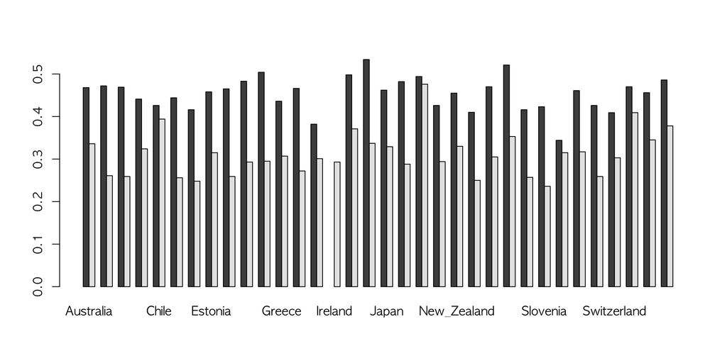

```r
barplot(as.matrix(t(Gini.b.a[, 2:3])), beside=TRUE, names.arg=Gini.b.a$Country)
```

개선도 순서(내림차순)를 `o.improvement`로 저장하여 지속적으로 활용.

```r
o.improvement<-order(Gini.b.a$Improvement, decreasing=TRUE)
Gini.b.a$Country[o.improvement]
```

```
##  [1] "Austria"         "Belgium"         "Germany"
##  [4] "Finland"         "Italy"           "Hungary"
##  [7] "Luxembourg"      "France"          "Czech_Republic"
## [10] "Slovenia"        "Portugal"        "Denmark"
## [13] "Sweden"          "Poland"          "Norway"
## [16] "Slovak_Republic" "Spain"           "Estonia"
## [19] "Japan"           "Australia"       "Netherlands"
## [22] "Greece"          "Israel"          "New_Zealand"
## [25] "Canada"          "United_Kingdom"  "United_States"
## [28] "Switzerland"     "Iceland"         "Turkey"
## [31] "Chile"           "South_Korea"     "Mexico"
## [34] "Ireland"
```

개선도 순서대로 막대를 늘어세우면,

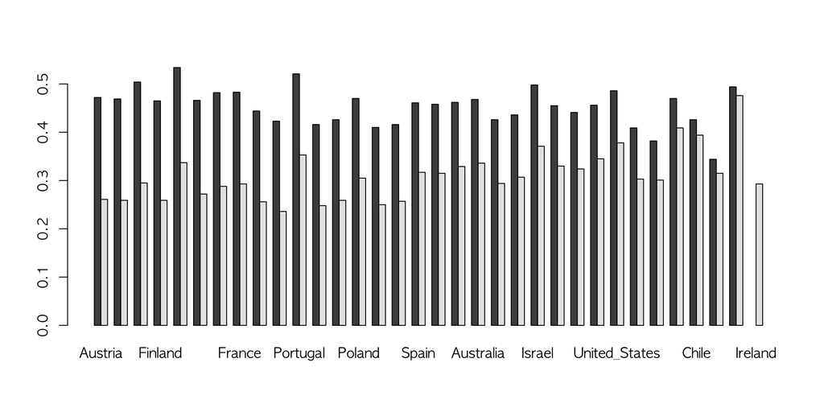

```r
barplot(as.matrix(t(Gini.b.a[o.improvement, 2:3])), beside=TRUE, names.arg=Gini.b.a$Country[o.improvement])
```

`las=2`를 이용하여 막대 이름을 눕힘.

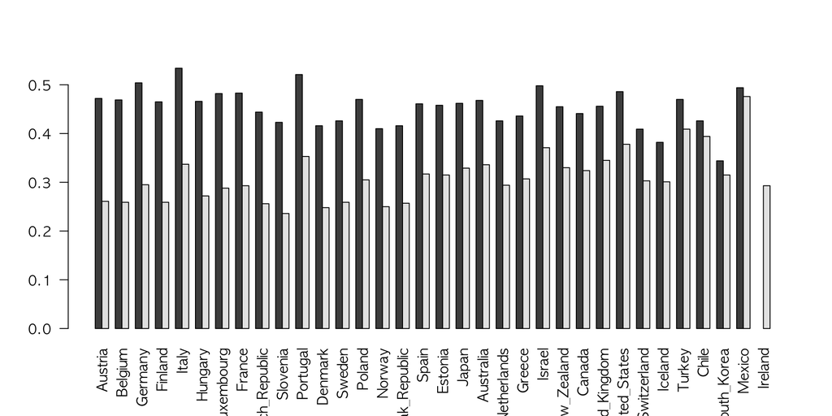

```r
barplot(as.matrix(t(Gini.b.a[o.improvement, 2:3])), beside=TRUE, names.arg=Gini.b.a$Country[o.improvement], las=2)
```

나라 이름이 가리지 않도록 `par("mai")`를 조정

```r
old.par<-par(no.readonly=TRUE)
par("mai")
```

```
## [1] 1.02 0.82 0.82 0.42
```

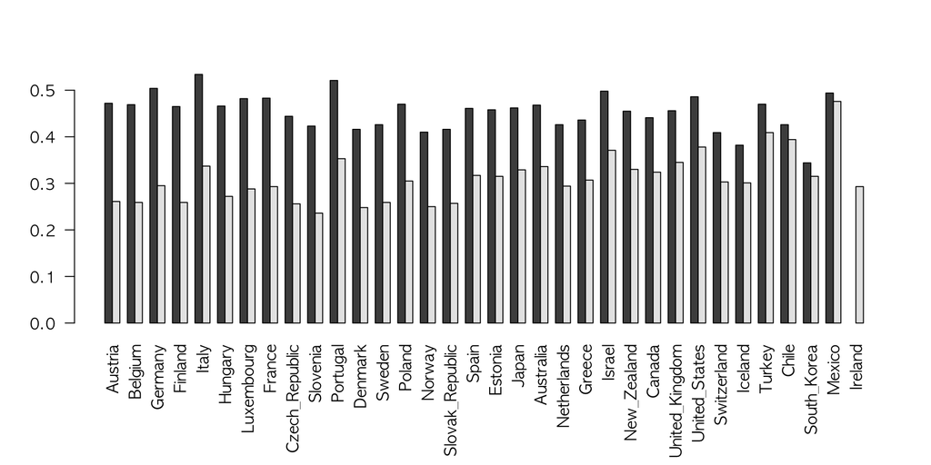

```r
par("mai"= c(1.5, 0.8, 0.8, 0.4))
barplot(as.matrix(t(Gini.b.a[o.improvement, 2:3])), beside=TRUE, names.arg=Gini.b.a$Country[o.improvement], las=2)
```

```r
par(old.par)
```

불평등이 심하다고 판단하는 Gini 계수 0.4를 경계로 나눠 보면,

```r
old.par<-par(no.readonly=TRUE)
par("mai")
```

```
## [1] 1.02 0.82 0.82 0.42
```

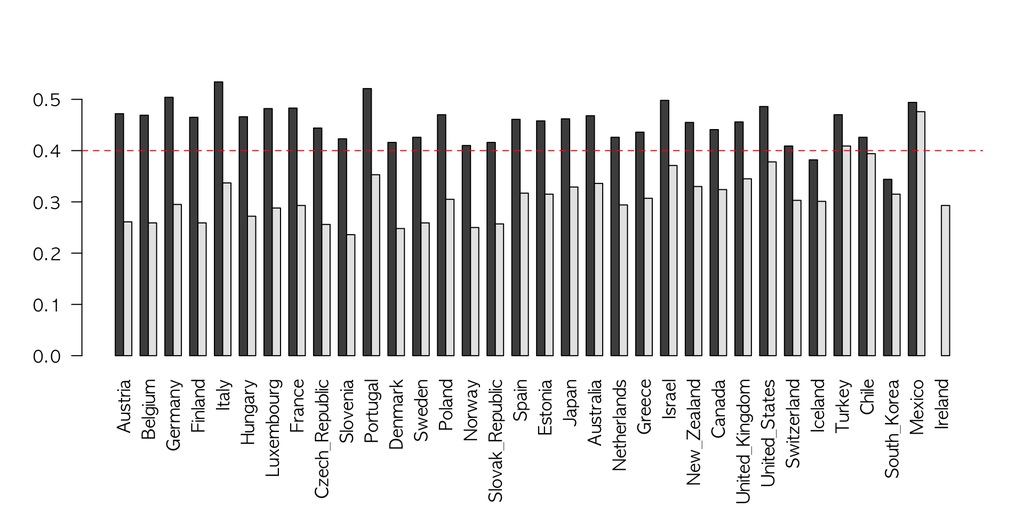

```r
par("mai"= c(1.5, 0.8, 0.8, 0.4))
barplot(as.matrix(t(Gini.b.a[o.improvement, 2:3])), beside=TRUE, names.arg=Gini.b.a$Country[o.improvement], las=2)
abline(h=0.4, lty=2, col="red")
```

```r
par(old.par)
```

범례와 메인 타이틀 추가. 좌표에 유의

```r
old.par<-par(no.readonly=TRUE)
par("mai")
```

```
## [1] 1.02 0.82 0.82 0.42
```

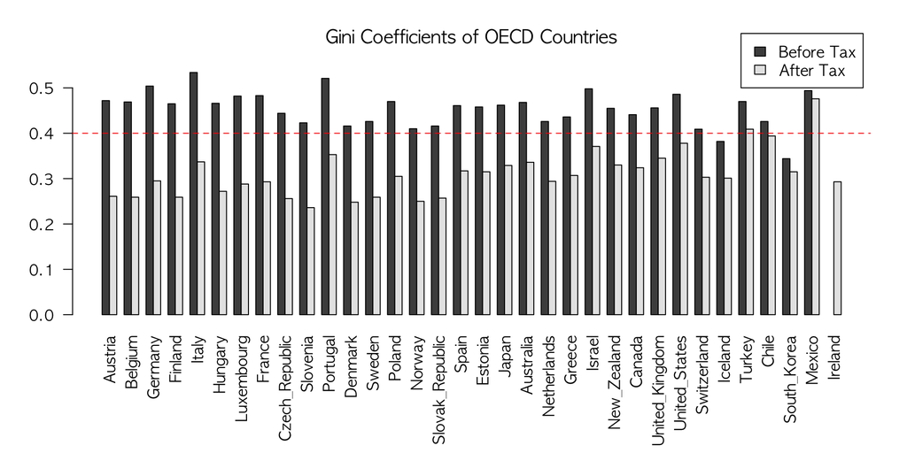

```r
par("mai"= c(1.5, 0.8, 0.8, 0.4))
barplot(as.matrix(t(Gini.b.a[o.improvement, 2:3])), beside=TRUE, names.arg=Gini.b.a$Country[o.improvement], legend.text=c("Before Tax", "After Tax"), args.legend=list(x=105, y=0.62), las=2)
abline(h=0.4, lty=2, col="red")
title(main="Gini Coefficients of OECD Countries")
```

```r
par(old.par)
```

이번에는 막대를 눕히는 방법을 생각해 보자. 옆으로 눕히면서 `las = 1` 로 설정하면,

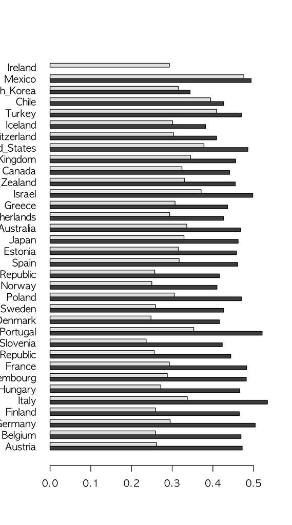

```r
barplot(as.matrix(t(Gini.b.a[o.improvement, 2:3])), beside=TRUE, horiz=TRUE, names.arg=Gini.b.a$Country[o.improvement], las=1)
```

역시 나라 이름이 가리지 않도록 `par("mai")`를 조정.

```r
old.par<-par(no.readonly=TRUE)
par("mai")
```

```
## [1] 1.02 0.82 0.82 0.42
```

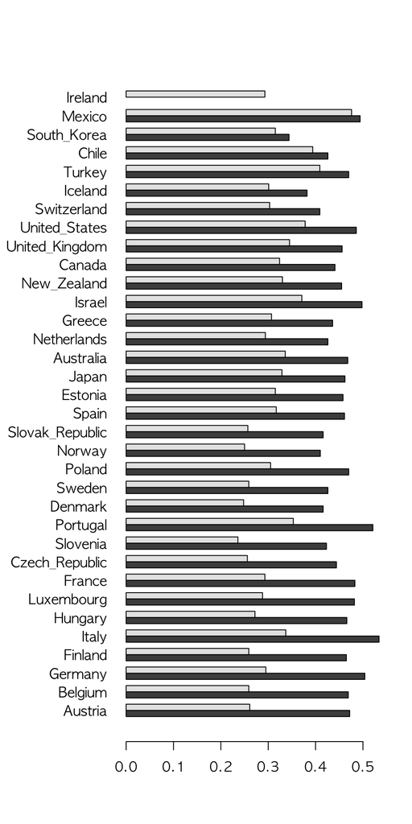

```r
par("mai"= c(1.0, 1.5, 0.8, 0.4))
barplot(as.matrix(t(Gini.b.a[o.improvement, 2:3])), beside=TRUE, horiz=TRUE, names.arg=Gini.b.a$Country[o.improvement], las=1)
```

```r
par(old.par)
```

개선도가 낮은 순서대로 밑에서 올라가도록 다시 그리면,

```r
old.par<-par(no.readonly=TRUE)
par("mai")
```

```
## [1] 1.02 0.82 0.82 0.42
```

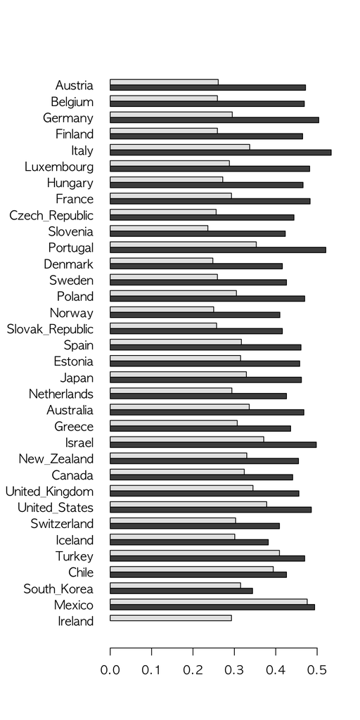

```r
par("mai"= c(1.0, 1.5, 0.8, 0.4))
barplot(as.matrix(t(Gini.b.a[order(Gini.b.a$Improvement, na.last=FALSE), 2:3])), beside=TRUE, horiz=TRUE, names.arg=Gini.b.a$Country[order(Gini.b.a$Improvement, na.last=FALSE)], las=1)
```

```r
par(old.par)
```

이 때, Ireland가 맨 위에 올라오는 게 보기 좋지 않으므로, `na.last=FALSE`를 추가한 것임.

세전 Gini 계수 0.4를 경계로 나눠보면

```r
old.par<-par(no.readonly=TRUE)
par("mai")
```

```
## [1] 1.02 0.82 0.82 0.42
```

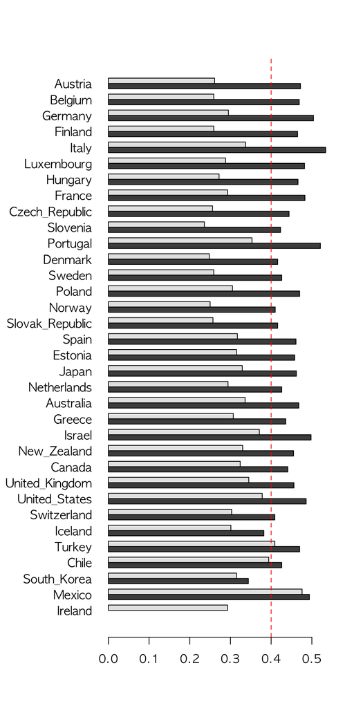

```r
par("mai"= c(1.0, 1.5, 0.8, 0.4))
barplot(as.matrix(t(Gini.b.a[order(Gini.b.a$Improvement, na.last=FALSE), 2:3])), beside=TRUE, horiz=TRUE, names.arg=Gini.b.a$Country[order(Gini.b.a$Improvement, na.last=FALSE)], las=1)
abline(v=0.4, lty=2, col="red")
```

```r
par(old.par)
```

범례 및 메인 타이틀 추가. 시행착오를 거쳐 구한 좌표에 유의할 것.

```r
old.par<-par(no.readonly=TRUE)
par("mai")
```

```
## [1] 1.02 0.82 0.82 0.42
```

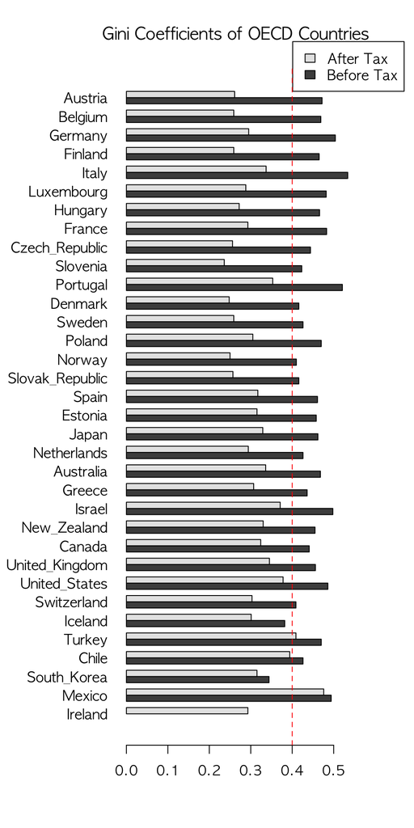

```r
par("mai"= c(1.0, 1.5, 0.8, 0.8))
barplot(as.matrix(t(Gini.b.a[order(Gini.b.a$Improvement, na.last=FALSE), 2:3])), beside=TRUE, horiz=TRUE, names.arg=Gini.b.a$Country[order(Gini.b.a$Improvement, na.last=FALSE)], legend.text=c("Before Tax", "After Tax"), args.legend=list(x=0.67, y=110), las=1)
abline(v=0.4, lty=2, col="red")
title(main="Gini Coefficients of OECD Countries")
```

```r
par(old.par)
```

## 뒷 마무리

```
save(file="Gini_OECD0504.rda", list=ls())
savehistory("Gini_OECD0504.Rhistory")
```